# Pruning & Rooting Phylogenetic Trees with ggTree

Kailyn Hanke

2025-03-30

# Goals

## Outputs

# Before you start

## Timing of this script

Let’s record how long this file took to run on the class server, which we will record at the end of the script.

```r
# What time did we start running this script?
start_time <- Sys.time()
```

## Set my seed

```r
# Any number can be chosen
set.seed(111111)
```

## Load Packages

```r
pacman::p_load(tidyverse, phyloseq, ggtree, phytools, tidytree, phylobase,
               install = FALSE)
```

## 1. Load Data files

```r
# Preprocessed phyloseq object
load("data/03_PreProcessing/raw_preprocessed_physeq.RData")

# Inspect the phyloseq object
raw_preprocessed_physeq
```

```
## phyloseq-class experiment-level object
## otu_table()   OTU Table:         [ 74848 taxa and 201 samples ]
## sample_data() Sample Data:       [ 201 samples by 55 sample variables ]
## tax_table()   Taxonomy Table:    [ 74848 taxa by 9 taxonomic ranks ]
```

```r
# Load in the tree!
unrooted_tree <- read.tree("data/04_PhylogeneticTree/ASVs_unrooted.tree")

# Take a look at the tree
unrooted_tree
```

```
##
## Phylogenetic tree with 74848 tips and 74846 internal nodes.
##
## Tip labels:
##   ASV_0012, ASV_44992, ASV_41984, ASV_41513, ASV_28999, ASV_57032, ...
## Node labels:
##   , 0.000, 0.457, 0.465, 0.000, 0.175, ...
##
## Unrooted; includes branch length(s).
```

```r
str(unrooted_tree)
```

```
## List of 5
##  $ edge       : int [1:149693, 1:2] 74849 74850 74851 74851 74852 74853 74854 74855 74856 74857 ...
##  $ edge.length: num [1:149693] 0.00055 0.00055 0.00055 0.00055 0.00053 0.00055 0.00054 0.00787 0.00054 0.00053 ...
##  $ Nnode      : int 74846
##  $ node.label : chr [1:74846] "" "0.000" "0.457" "0.465" ...
##  $ tip.label  : chr [1:74848] "ASV_0012" "ASV_44992" "ASV_41984" "ASV_41513" ...
##  - attr(*, "class")= chr "phylo"
##  - attr(*, "order")= chr "cladewise"
```

# 2. Merge Unrooted Tree & `raw_preprocessed_physeq`

Now that we’ve loaded in both our `raw_preprocessed_physeq` and the unrooted tree, let’s merge them into one phyloseq object that can be used to plot the tree with ggtree.

```r
# Intuition check
stopifnot(ntaxa(raw_preprocessed_physeq) == ntaxa(unrooted_tree))
# No news is good news!

# Merge the tree with the phyloseq object
unrooted_physeq <-
  merge_phyloseq(raw_preprocessed_physeq, unrooted_tree)

# Let's take a look!
unrooted_physeq
```

```
## phyloseq-class experiment-level object
## otu_table()   OTU Table:         [ 74848 taxa and 201 samples ]
## sample_data() Sample Data:       [ 201 samples by 55 sample variables ]
## tax_table()   Taxonomy Table:    [ 74848 taxa by 9 taxonomic ranks ]
## phy_tree()    Phylogenetic Tree: [ 74848 tips and 74846 internal nodes ]
```

# 3. Visualize and inspect tree with [ggtree](https://besjournals.onlinelibrary.wiley.com/doi/full/10.1111/2041-210X.12628).

Now, let’s take a look

## Kingdom Level Tree

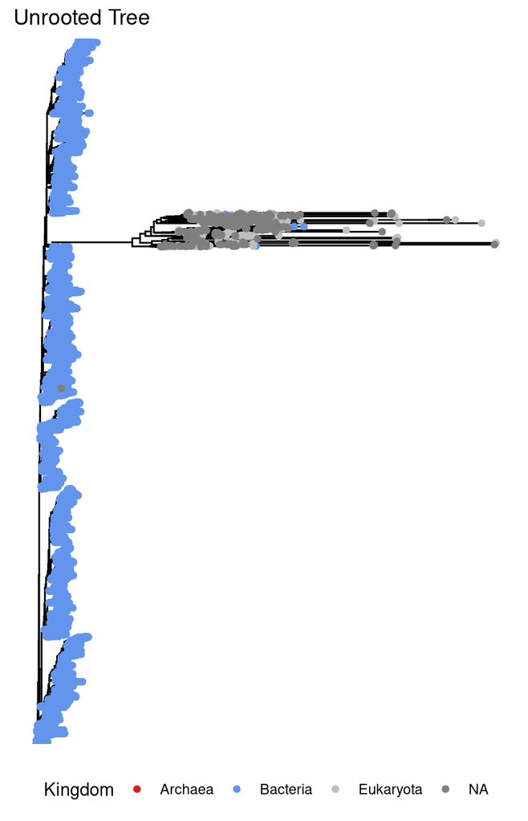

```r
# Make a basic tree with the domains
kingdom_tree <-
  ggtree(unrooted_physeq) +
  # color tips by kingdom
  geom_tippoint(mapping = aes(color = Kingdom)) +
  # add a title
  labs(title = "Unrooted Tree") +
  scale_color_manual(values = c("firebrick3", "cornflowerblue", "grey")) +
  # Move the legend to the bottom of the tree
  theme(legend.position = "bottom")

# Look at it
kingdom_tree
```

```r
# Check if tree is rooted
is.rooted(unrooted_tree) # should be TRUE
```

```
## [1] FALSE
```

# 4. Long Branches?

Now, let’s think about the quality of our tree. Evaluate that kingdom tree above…

INTERPRETATION #1: Are there any suspect branches in the raw, unrooted tree? Or does your tree look “clean”? Why or why not?

## 4a. Evaluate Long Branches

### Kingdom Tree with Node Labels

Let’s put labels on our tree so we have a bit more flexibility

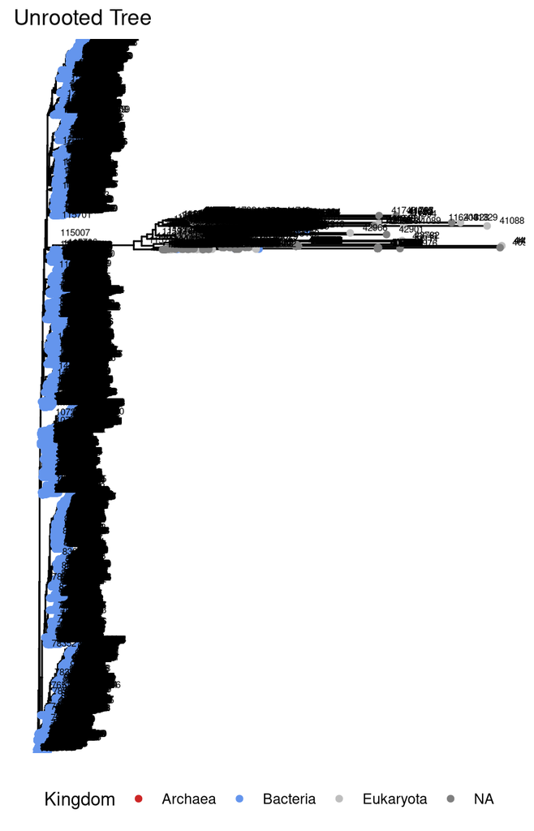

```r
kingdom_node_tree <-
  kingdom_tree +
  # Add the node label
  geom_text(aes(label=node), hjust= -0.5, vjust = -0.3, size = 2)

# Plot the tree
kingdom_node_tree
```

In the phylogeny above, it is extremely dense and hard to tell what the labels are on the nodes, especially for the bacteria with extremely long branches sitting within the eukaryotes and ASVs that were labeled “NA”. In order to try and distinguish some long bacterial nodes, I will first zoom in on node #115007, as it is one of the only node labels I can read. I repeated the process of identifying node #’s and looking for ancestors about 20 times in order to try and idenitfy an appropriate node to remove the eukaryotic ASVs. To keep this document easy to follow and to save time when I knot, I have only included the code for the final node I inspected.

### Evaluate node #115007 and #115707

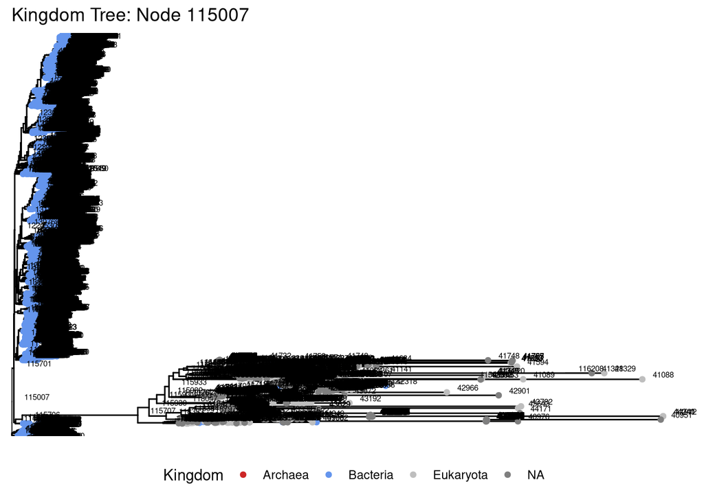

```r
# View a specific clade
# Zoom in on node that looks potentially suspicious
viewClade(kingdom_node_tree +
          labs(title = "Kingdom Tree: Node 115007"),
          node = 115007)
```

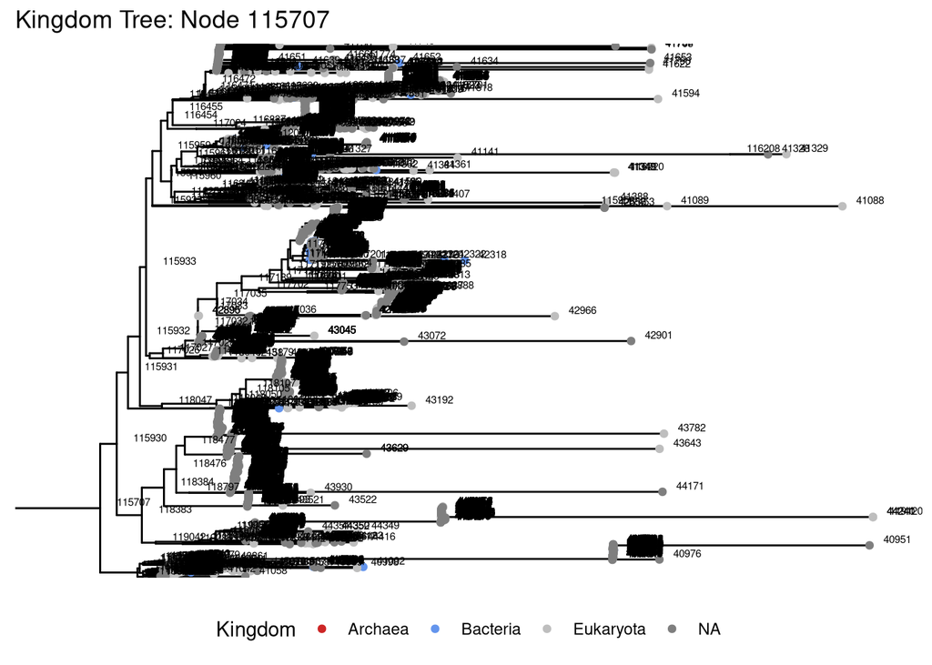

```r
#checking115707
viewClade(kingdom_node_tree +
          labs(title = "Kingdom Tree: Node 115707"),
          node = 115707)
```

```r
# Lets see its ancestors, which will tell us each node as it steps up.
# It's ideal to look a couple nodes up but not too far!
tidytree::ancestor(unrooted_tree, 115707)
```

```
##  [1] 115706 115703 115702 115701 115007 114420 114419 111857 111856 111801
## [11] 111800 111644 111010 111009 110069 110013 110012 110011 107266 107199
## [21] 106908 106907 106905 106672 106671 101441  78353  78352  76522  76497
## [31]  76389  76388  76387  76386  76385  76023  76020  76019  76018  76008
## [41]  76007  76006  76004  76003  76002  75938  75188  75187  75185  75184
## [51]  75182  75181  74849
```

```r
tidytree::ancestor(unrooted_tree, 115706)
```

```
##  [1] 115703 115702 115701 115007 114420 114419 111857 111856 111801 111800
## [11] 111644 111010 111009 110069 110013 110012 110011 107266 107199 106908
## [21] 106907 106905 106672 106671 101441  78353  78352  76522  76497  76389
## [31]  76388  76387  76386  76385  76023  76020  76019  76018  76008  76007
## [41]  76006  76004  76003  76002  75938  75188  75187  75185  75184  75182
## [51]  75181  74849
```

```r
# Let's evaluate some more ancestors with no clear labels

#viewClade(kingdom_node_tree, 115703)
#viewClade(kingdom_node_tree, 115702)

# Commented out to save time while knitting!
```

Here I will inspect the large clade with eukaryotes, and will remove it in the pruning step.

```r
# Or if there are two nodes that we can see we can find its MRCA
## create tibble of tree to identify offspring
tree_tib <- as_tibble(unrooted_physeq@phy_tree)

# Inspect
head(tree_tib)
```

```
## # A tibble: 6 × 4
##   parent  node branch.length label
##    <int> <int>         <dbl> <chr>
## 1  74851     1       0.00055 ASV_0012
## 2  74860     2       0.0233  ASV_44992
## 3  74860     3       0.00686 ASV_41984
## 4  74859     4       0.0104  ASV_41513
## 5  74861     5       0.0026  ASV_28999
## 6  74862     6       0.0435  ASV_57032
```

```r
str(tree_tib)
```

```
## tbl_tree [149,694 × 4] (S3: tbl_tree/tbl_df/tbl/data.frame)
##  $ parent       : int [1:149694] 74851 74860 74860 74859 74861 74862 74862 74868 74869 74870 ...
##  $ node         : int [1:149694] 1 2 3 4 5 6 7 8 9 10 ...
##  $ branch.length: num [1:149694] 0.00055 0.0233 0.00686 0.01042 0.0026 ...
##  $ label        : chr [1:149694] "ASV_0012" "ASV_44992" "ASV_41984" "ASV_41513" ...
```

```r
# lets look at the long branch
mrca_node_115706 <- tidytree::MRCA(unrooted_tree, .node1 = 115706, .node2 = 115702)

# Inspect
mrca_node_115706
```

```
## [1] 115702
```

```r
## create dataframe to view ASVs and taxa info and to pull the ASVs
node_115706 <-
  offspring(tree_tib, mrca_node_115706, tiponly = TRUE) %>%
  as.data.frame() %>%
  pull(label)

# Inspect
#node_115706

# Now, let's pull out the taxonomy information, including the ASV sequence!
node_115706_df <-
  unrooted_physeq %>%
  tax_table() %>%
  as.data.frame() %>%
  filter(ASV %in% node_115706)

# Take a look:
glimpse(node_115706_df)
```

```
## Rows: 3,600
## Columns: 9
## $ Kingdom <chr> "Bacteria", "Bacteria", "Bacteria", "Bacteria", "Eukaryota", "…
## $ Phylum  <chr> "Bacillota", "Bacteroidota", "Pseudomonadota", NA, NA, NA, NA,…
## $ Class   <chr> "Bacilli", "Bacteroidia", NA, NA, NA, NA, NA, NA, NA, NA, NA, …
## $ Order   <chr> NA, NA, NA, NA, NA, NA, NA, NA, NA, NA, NA, NA, NA, NA, NA, NA…
## $ Family  <chr> NA, NA, NA, NA, NA, NA, NA, NA, NA, NA, NA, NA, NA, NA, NA, NA…
## $ Genus   <chr> NA, NA, NA, NA, NA, NA, NA, NA, NA, NA, NA, NA, NA, NA, NA, NA…
## $ Species <chr> NA, NA, NA, NA, NA, NA, NA, NA, NA, NA, NA, NA, NA, NA, NA, NA…
## $ ASV     <chr> "ASV_55853", "ASV_54737", "ASV_72467", "ASV_65537", "ASV_71660…
## $ ASVseqs <chr> "TAGGGAATCTTCCGCAATGGGCGAAAGCCTGACGGAGCAACGCCGCGTGAGTGATGAAGGT…
```

```r
# look at counts of the ASVs
unrooted_physeq %>%
  subset_taxa(., ASV %in% node_115706_df$ASV) %>%
  otu_table() %>%
  data.frame() %>%
  colSums()
```

```
## ERR3141386 ERR3141387 ERR3141388 ERR3141389 ERR3141390 ERR3141391 ERR3141392
##          0         15          2          4        117          0         12
## ERR3141393 ERR3141394 ERR3141395 ERR3141396 ERR3141397 ERR3141398 ERR3141399
##          2         20          6         44          0         41          5
## ERR3141400 ERR3141401 ERR3141402 ERR3141403 ERR3141404 ERR3141405 ERR3141406
##          3          0         16          2          2        109          6
## ERR3141407 ERR3141408 ERR3141409 ERR3141410 ERR3141411 ERR3141412 ERR3141413
##          1          0          0         11         16         15         10
## ERR3141414 ERR3141415 ERR3141416 ERR3141417 ERR3141418 ERR3141419 ERR3141420
##          4          3         12          0          2          2         29
## ERR3141421 ERR3141422 ERR3141423 ERR3141424 ERR3141425 ERR3141426 ERR3141427
##          0          3         58         40         26          4          0
## ERR3141428 ERR3141429 ERR3141430 ERR3141431 ERR3141432 ERR3141433 ERR3141434
##          0          2          2          6          2          0          6
## ERR3141435 ERR3141436 ERR3141437 ERR3141438 ERR3141439 ERR3141440 ERR3141441
##          0          3          0         25         20         12         24
## ERR3141442 ERR3141443 ERR3141444 ERR3141445 ERR3141446 ERR3141447 ERR3141448
##         15         11         27         99         26         10         36
## ERR3141449 ERR3141450 ERR3141451 ERR3141452 ERR3141453 ERR3141454 ERR3141455
##         31         14          8          2         24          2         34
## ERR3141456 ERR3141457 ERR3141458 ERR3141459 ERR3141460 ERR3141461 ERR3141462
##         28        104         67         43         31          4          6
## ERR3141463 ERR3141464 ERR3141465 ERR3141466 ERR3141467 ERR3141468 ERR3141469
##          5          0          7          0          6          0          0
## ERR3141470 ERR3141471 ERR3141472 ERR3141473 ERR3141474 ERR3141475 ERR3141476
##          0          0          0          0          6          0          0
## ERR3141477 ERR3141478 ERR3141479 ERR3141480 ERR3141481 ERR3141482 ERR3141483
##          2         14          0          5          0          2         11
## ERR3141484 ERR3141485 ERR3141486 ERR3141487 ERR3141488 ERR3141489 ERR3141490
##          0          5         14         20          2          0         15
## ERR3141491 ERR3141492 ERR3141493 ERR3141494 ERR3141495 ERR3141496 ERR3141497
##         22          9          0          4         26          0         30
## ERR3141498 ERR3141499 ERR3141500 ERR3141501 ERR3141502 ERR3141503 ERR3141504
##         19          0         15          0          2          0          0
## ERR3141505 ERR3141506 ERR3141507 ERR3141508 ERR3141509 ERR3141510 ERR3141511
##         63          0          4         10          0          5          2
## ERR3141512 ERR3141513 ERR3141514 ERR3141515 ERR3141516 ERR3141517 ERR3141518
##          0          4         13         47         20         80          2
## ERR3141519 ERR3141520 ERR3141521 ERR3141522 ERR3141523 ERR3141524 ERR3141525
##          4          0         19          2          0          2         33
## ERR3141526 ERR3141527 ERR3141528 ERR3141529 ERR3141530 ERR3141531 ERR3141532
##          3         11         16         17          3         72          0
## ERR3141533 ERR3141534 ERR3141535 ERR3141536 ERR3141537 ERR3141538 ERR3141539
##          6         36          0          8         17          0          0
## ERR3141540 ERR3141541 ERR3141542 ERR3141543 ERR3141544 ERR3141545 ERR3141546
##         13         13          2          0          2          5          0
## ERR3141547 ERR3141548 ERR3141549 ERR3141550 ERR3141551 ERR3141552 ERR3141553
##          2          3          0          0         16          0          9
## ERR3141554 ERR3141555 ERR3141556 ERR3141557 ERR3141558 ERR3141559 ERR3141560
##          0          2          0          0          2         32          2
## ERR3141561 ERR3141562 ERR3141563 ERR3141564 ERR3141565 ERR3141566 ERR3141567
##          0          0          6          0          0          0          2
## ERR3141568 ERR3141569 ERR3141570 ERR3141571 ERR3141572 ERR3141573 ERR3141574
##          4          2          7          5          2          0          0
## ERR3141575 ERR3141576 ERR3141577 ERR3143461 ERR3143463 ERR3143467 ERR3143468
##          4          0          0       1776       1491       1616       1713
## ERR3143469 ERR3143471 ERR3143472 ERR3143473 ERR3143475
##       1872       2590       1467       3596       2510
```

## 4b. Prune your tree

Pruning my eukaryotic clade!

```r
# Function from Joey McMurdie: https://github.com/joey711/phyloseq/issues/652
pop_taxa = function(physeq, badTaxa){
  allTaxa <-  taxa_names(physeq)
  allTaxa <- allTaxa[!(allTaxa %in% badTaxa)]
  return(prune_taxa(allTaxa, physeq))
  }

# Let's use the pop_taxa function :)
# Recreate a phyloseq object without your unwanted ASV or node
# Lets use the example ASVs above from node_3315_df
unrooted_physeq_rm115706 <-
  unrooted_physeq %>%
  pop_taxa(., node_115706_df$ASV)

# Check it
unrooted_physeq_rm115706

# Intuition Check: How many differ???
ntaxa(unrooted_physeq) - ntaxa(unrooted_physeq_rm115706)

# Visually inspect
ggtree(unrooted_physeq_rm115706) +
  geom_tippoint(mapping = aes(color = Kingdom))
```

[output not shown]

Investigate to see if there are any archaeal ASVs.

```r
# Is the tree rooted?
tidytree::is.rooted(phy_tree(unrooted_physeq))
```

```
## [1] FALSE
```

```r
# but first find the ASVs that are Archaea
archaeal_ASVs <-
  tax_table(unrooted_physeq) %>%
  as.data.frame() %>%
  filter(Kingdom == "Archaea") %>%
  pull(ASV)

# How many archaeal ASVs?
length(archaeal_ASVs)
```

```
## [1] 10
```

```r
archaeal_ASVs
```

```
##  [1] "ASV_43629" "ASV_67058" "ASV_68173" "ASV_62956" "ASV_69101" "ASV_69898"
##  [7] "ASV_65365" "ASV_59191" "ASV_59910" "ASV_63820"
```

```r
#there are 10!

#Now find how many ASVs that are Archaea in my pruned dataset
#archaeal_ASVs_rm115706 <-
  #tax_table(unrooted_physeq_rm115706) %>%
  #as.data.frame() %>%
  #filter(Kingdom == "Archaea") %>%
  #pull(ASV)

#length(archaeal_ASVs_rm115706)
#archaeal_ASVs_rm115706
#note there are ten here too!

# find the node that encompasses all Archaea
archaeal_node <-
  phytools::findMRCA(unrooted_tree,
                     tips = archaeal_ASVs, type = "node")

# Inspect
archaeal_node # node = 141274
```

```
## [1] 141274
```

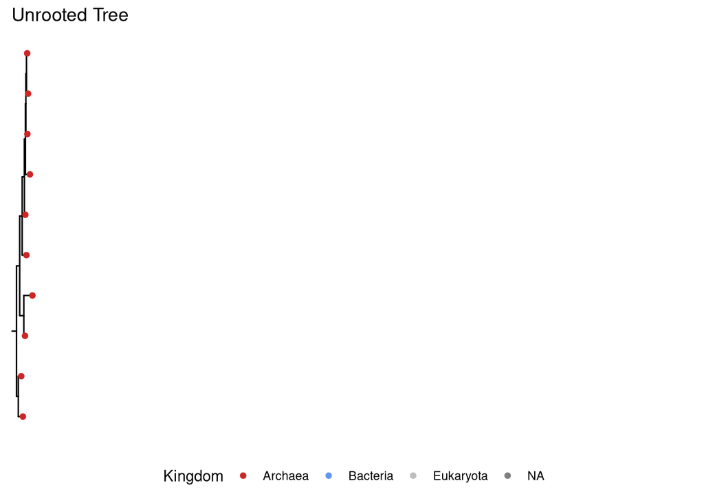

```r
# View clade to check it out
viewClade(kingdom_tree, archaeal_node)
```

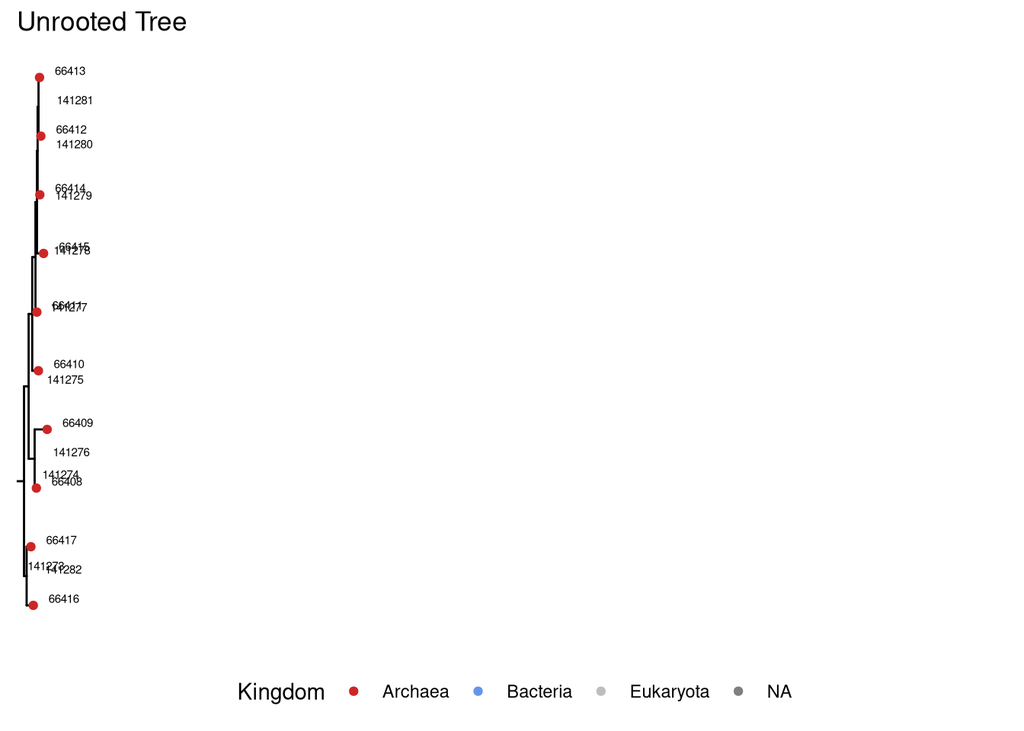

```r
viewClade(kingdom_node_tree, archaeal_node)
```

Highlighting the node with archaea

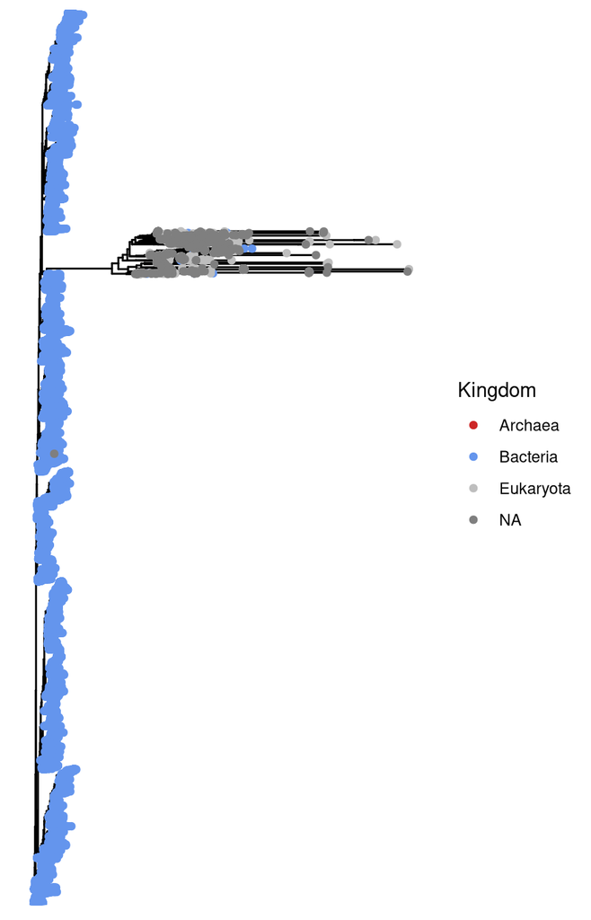

```r
# Let's highlight!
node_115706_archaea <-
  ggtree(unrooted_physeq) +
  geom_tippoint(mapping = aes(color = Kingdom), size = 1.5) +
  #geom_text(aes(label = node), hjust = -0.7, vjust = -0.2, size = 2) +
  geom_highlight(node = archaeal_node, fill = "goldenrod1") +
  scale_color_manual(values = c("firebrick3", "cornflowerblue", "grey"))

#Note: I probably should have named it with the archaeal node 141274

# Visualize it
node_115706_archaea
```

```r
#Note: I probably should have named it with the archaeal node 141274

#running it on my pruned tree
#node_141274_archaea <-
  #ggtree(unrooted_physeq_rm115706) +
  #geom_tippoint(mapping = aes(color = Kingdom), size = 1.5) +
  #geom_text(aes(label = node), hjust = -0.7, vjust = -0.2, size = 2) +
  #geom_highlight(node = archaeal_node, fill = "goldenrod1") +
  #scale_color_manual(values = c("firebrick3", "cornflowerblue", "grey"))

#visualize pruned tree
#node_141274_archaea

#Despite highlighting the archaeal node in my code, I was not able to actually see the node highlighted in my plot (I think that there was too much other data covering the highlighted portion up)

#Now I am going to remove my archaeal node in addition to my eukaryotic one, and then consult with Mar/Sophia during office hours to see if this removal was too crude/extreme.
```

Pruning out the archaeal node in addition to the eukaryotic one

```r
#Inspect archaeal ASV
# lets look at the long branch
mrca_node_141274 <- tidytree::MRCA(unrooted_tree, .node1 = 141274, .node2 = 141275)

# Inspect
mrca_node_141274
```

```
## [1] 141273
```

```r
## create dataframe to view ASVs and taxa info and to pull the ASVs
node_141274 <-
  offspring(tree_tib, mrca_node_141274, tiponly = TRUE) %>%
  as.data.frame() %>%
  pull(label)

# Inspect
node_141274
```

```
##  [1] "ASV_70794" "ASV_43629" "ASV_67058" "ASV_68173" "ASV_62956" "ASV_69101"
##  [7] "ASV_69898" "ASV_65365" "ASV_59191" "ASV_59910" "ASV_63820"
```

```r
# Now, let's pull out the taxonomy information, including the ASV sequence!
node_141274_df <-
  unrooted_physeq %>%
  tax_table() %>%
  as.data.frame() %>%
  filter(ASV %in% node_141274)

# Take a look:
glimpse(node_141274_df)
```

```
## Rows: 11
## Columns: 9
## $ Kingdom <chr> "Bacteria", "Archaea", "Archaea", "Archaea", "Archaea", "Archa…
## $ Phylum  <chr> "Bacillota", "Methanobacteriota", "Methanobacteriota", "Methan…
## $ Class   <chr> "Bacilli", "Methanobacteria", "Methanobacteria", "Methanobacte…
## $ Order   <chr> NA, "Methanobacteriales", "Methanobacteriales", "Methanobacter…
## $ Family  <chr> NA, "Methanobacteriaceae", "Methanobacteriaceae", "Methanobact…
## $ Genus   <chr> NA, NA, NA, NA, "Methanobrevibacter", "Methanobrevibacter", NA…
## $ Species <chr> NA, NA, NA, NA, NA, NA, NA, NA, NA, NA, NA
## $ ASV     <chr> "ASV_70794", "ASV_43629", "ASV_67058", "ASV_68173", "ASV_62956…
## $ ASVseqs <chr> "TAGGGAATCTTCCGCAATGGGCGAAAGCCTGACGGAGCAACGCCGCGTGAGTGATGAAGGT…
```

```r
# look at counts of the ASVs
unrooted_physeq %>%
  subset_taxa(., ASV %in% node_141274_df$ASV) %>%
  otu_table() %>%
  data.frame() %>%
  colSums()
```

```
## ERR3141386 ERR3141387 ERR3141388 ERR3141389 ERR3141390 ERR3141391 ERR3141392
##          0          0          0          0          0          0          0
## ERR3141393 ERR3141394 ERR3141395 ERR3141396 ERR3141397 ERR3141398 ERR3141399
##          0          0          0          2          0          0          0
## ERR3141400 ERR3141401 ERR3141402 ERR3141403 ERR3141404 ERR3141405 ERR3141406
##          0          0          0          0          0          0          0
## ERR3141407 ERR3141408 ERR3141409 ERR3141410 ERR3141411 ERR3141412 ERR3141413
##          0          0          0          0          0          0          0
## ERR3141414 ERR3141415 ERR3141416 ERR3141417 ERR3141418 ERR3141419 ERR3141420
##          0          2          0          0          0          0          0
## ERR3141421 ERR3141422 ERR3141423 ERR3141424 ERR3141425 ERR3141426 ERR3141427
##          0          0          0          0          0          0          0
## ERR3141428 ERR3141429 ERR3141430 ERR3141431 ERR3141432 ERR3141433 ERR3141434
##          0          0          0          0          0          0          0
## ERR3141435 ERR3141436 ERR3141437 ERR3141438 ERR3141439 ERR3141440 ERR3141441
##          0          0          0          0          0          0          0
## ERR3141442 ERR3141443 ERR3141444 ERR3141445 ERR3141446 ERR3141447 ERR3141448
##          0          0          2          0          0          0          0
## ERR3141449 ERR3141450 ERR3141451 ERR3141452 ERR3141453 ERR3141454 ERR3141455
##          0          0          0          0          4          0          0
## ERR3141456 ERR3141457 ERR3141458 ERR3141459 ERR3141460 ERR3141461 ERR3141462
##          0          0          0          0          0          0          0
## ERR3141463 ERR3141464 ERR3141465 ERR3141466 ERR3141467 ERR3141468 ERR3141469
##          0          0          0          0          0          0          0
## ERR3141470 ERR3141471 ERR3141472 ERR3141473 ERR3141474 ERR3141475 ERR3141476
##          0          0          0          0          0          0          0
## ERR3141477 ERR3141478 ERR3141479 ERR3141480 ERR3141481 ERR3141482 ERR3141483
##          0          0          0          0          0          0          0
## ERR3141484 ERR3141485 ERR3141486 ERR3141487 ERR3141488 ERR3141489 ERR3141490
##          0          0          0          2          0          0          0
## ERR3141491 ERR3141492 ERR3141493 ERR3141494 ERR3141495 ERR3141496 ERR3141497
##          0          0          0          0          0          0          0
## ERR3141498 ERR3141499 ERR3141500 ERR3141501 ERR3141502 ERR3141503 ERR3141504
##          0          0          0          0          0          0          0
## ERR3141505 ERR3141506 ERR3141507 ERR3141508 ERR3141509 ERR3141510 ERR3141511
##          0          0          0          0          0          0          0
## ERR3141512 ERR3141513 ERR3141514 ERR3141515 ERR3141516 ERR3141517 ERR3141518
##          2          0          0          0          0          0          0
## ERR3141519 ERR3141520 ERR3141521 ERR3141522 ERR3141523 ERR3141524 ERR3141525
##          0          0          0          0          0          0          0
## ERR3141526 ERR3141527 ERR3141528 ERR3141529 ERR3141530 ERR3141531 ERR3141532
##          2          0          0          0          0          0          3
## ERR3141533 ERR3141534 ERR3141535 ERR3141536 ERR3141537 ERR3141538 ERR3141539
##          0          0          0          0          0          0          0
## ERR3141540 ERR3141541 ERR3141542 ERR3141543 ERR3141544 ERR3141545 ERR3141546
##          0          0          0          2          3          0          0
## ERR3141547 ERR3141548 ERR3141549 ERR3141550 ERR3141551 ERR3141552 ERR3141553
##          0          0          0          0          0          0          0
## ERR3141554 ERR3141555 ERR3141556 ERR3141557 ERR3141558 ERR3141559 ERR3141560
##          0          0          0          0          0          0          0
## ERR3141561 ERR3141562 ERR3141563 ERR3141564 ERR3141565 ERR3141566 ERR3141567
##          0          2          0          0          0          0          0
## ERR3141568 ERR3141569 ERR3141570 ERR3141571 ERR3141572 ERR3141573 ERR3141574
##          0          0          0          0          0          0          0
## ERR3141575 ERR3141576 ERR3141577 ERR3143461 ERR3143463 ERR3143467 ERR3143468
##          0          0          0          0          0          0          0
## ERR3143469 ERR3143471 ERR3143472 ERR3143473 ERR3143475
##          0          0          0          0          0
```

```r
# Function from Joey McMurdie: https://github.com/joey711/phyloseq/issues/652
pop_taxa = function(physeq, badTaxa){
  allTaxa <-  taxa_names(physeq)
  allTaxa <- allTaxa[!(allTaxa %in% badTaxa)]
  return(prune_taxa(allTaxa, physeq))
  }

#Time to prune both euk and archaeal
unrooted_physeq_rm115706_rmarchaea <-
  unrooted_physeq %>%
  pop_taxa(., node_115706_df$ASV) %>%
  pop_taxa(., node_141274_df$ASV)

# Check it
unrooted_physeq_rm115706_rmarchaea
```

```
## phyloseq-class experiment-level object
## otu_table()   OTU Table:         [ 71237 taxa and 201 samples ]
## sample_data() Sample Data:       [ 201 samples by 55 sample variables ]
## tax_table()   Taxonomy Table:    [ 71237 taxa by 9 taxonomic ranks ]
## phy_tree()    Phylogenetic Tree: [ 71237 tips and 71235 internal nodes ]
```

```r
# Intuition Check: How many differ???
ntaxa(unrooted_physeq) - ntaxa(unrooted_physeq_rm115706_rmarchaea)
```

```
## [1] 3611
```

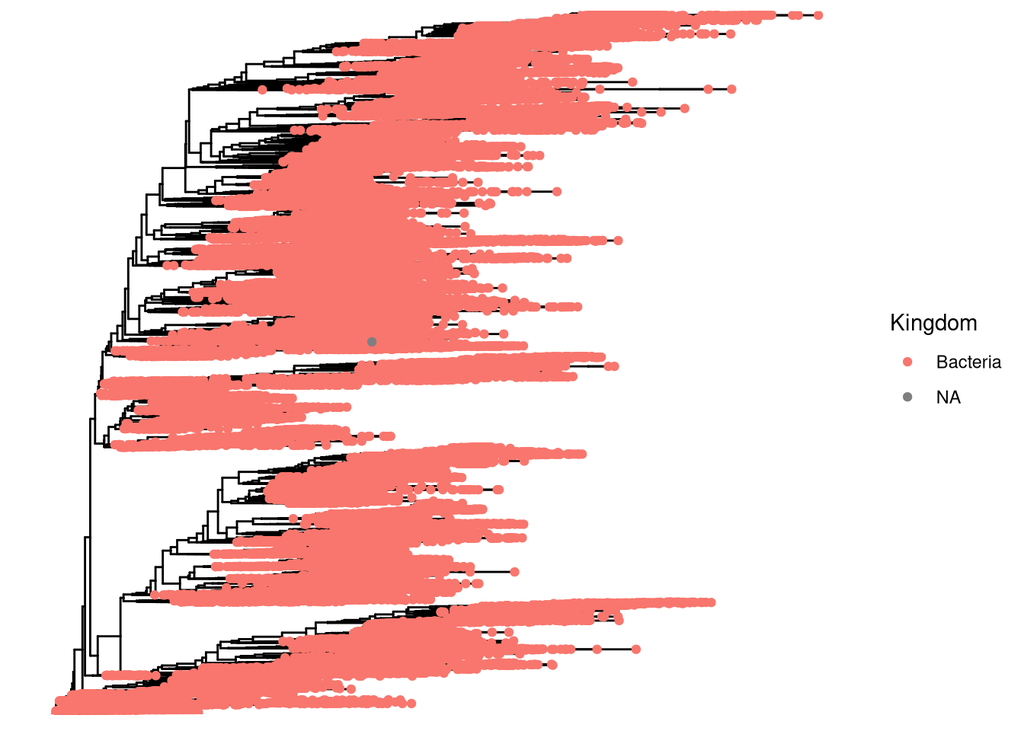

```r
# Visually inspect
ggtree(unrooted_physeq_rm115706_rmarchaea) +
  geom_tippoint(mapping = aes(color = Kingdom))
```

INTERPRETATION #2: Were there any long branches in the unrooted tree? If so, did you decide to remove any ASVs from your tree? Why or why not? What data convinced you to remove each of the ASVs?

Yes, in my data I removed the long branches in the eukaryotic clade in addition to the clade that contained the archaea. Since I used primers for the V3-V4 region, I was not expecting to get many archaea, and pruned the 10 I did get from my tree as I will be doing midpoint rooting. Note that I did not remove any of the longer bacterial branches outside of these clades. In office hours next week I plan to ask a few clarifying questions about removal parameters in this step, so moving forward I can feel confident about how I processed my data! What I have right now seems like a good starting point, but I want to acknowledge that I may need to refine further.

# 5. Root the Tree

Now that we’ve pruned the trees of potentially contaminating ASVs, it’s time to root!

### 6b. Merge phyloseq: Midpoint Rooted Tree

```r
# Check to see if tree is rooted.. expect it to be false
is.rooted(phy_tree(unrooted_physeq_rm115706_rmarchaea))
```

```
## [1] FALSE
```

```r
# Let's midpoint root the tree
midpoint_rooted_tree <-
  unrooted_physeq_rm115706_rmarchaea %>%
  phy_tree() %>%
  phytools::midpoint.root()

# Is the new tree rooted? Should be TRUE!
is.rooted(midpoint_rooted_tree)
```

```
## [1] TRUE
```

```r
# Assign to a new phyloseq object!
# Merge tree with the raw_preprocessed physeq
midpoint_rooted_physeq <-
  merge_phyloseq(raw_preprocessed_physeq, midpoint_rooted_tree)
```

### Plot Midpoint Rooted Tree

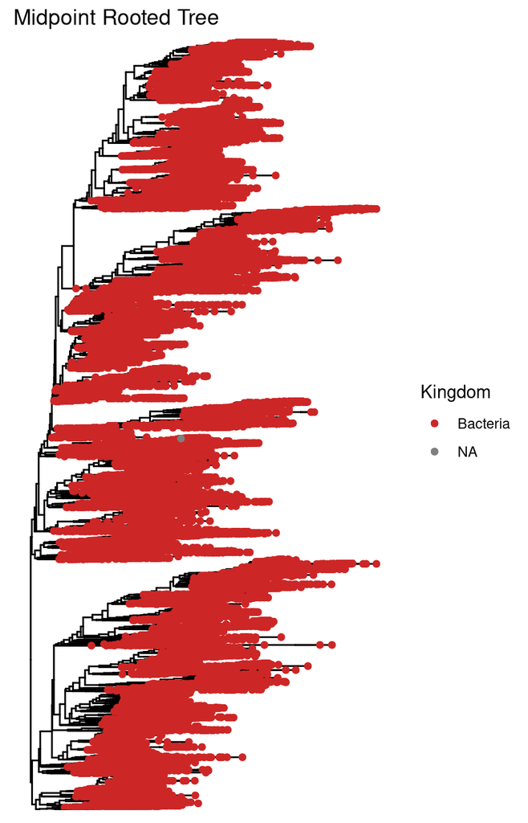

```r
# Quick inspection of tree
midpoint_rooted_tree_plot <-
  ggtree(midpoint_rooted_physeq) +
  geom_tippoint(mapping = aes(color = Kingdom)) +
  geom_tippoint(aes(color = Kingdom)) +
  labs(title = "Midpoint Rooted Tree") +
  scale_color_manual(values = c("firebrick3", "cornflowerblue", "grey"))

# Look at the tree
midpoint_rooted_tree_plot
```

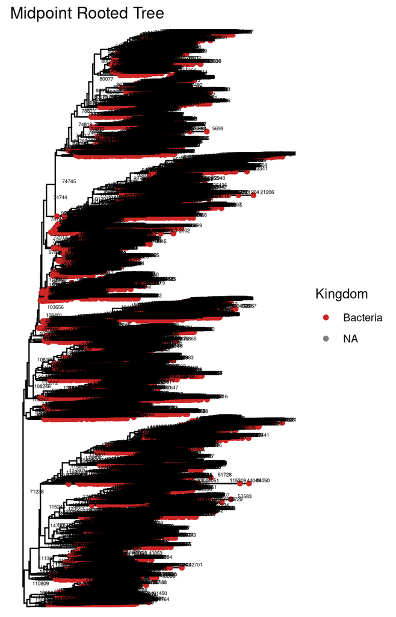

```r
# Add nodes
midpoint_rooted_tree_node_plot <-
  midpoint_rooted_tree_plot +
  geom_text(aes(label = node), hjust = -0.5, vjust = -0.3, size = 1.5)

# View it
midpoint_rooted_tree_node_plot
```

## 7. Save phyloseq objects

### Save individual phyloseq objects

```r
# Save midpoint rooted phyloseq object
save(midpoint_rooted_physeq,
     file = "data/04_PhylogeneticTree/midpoint_rooted_physeq.RData")
```

# Final info for Reproducibility

## Check Render Time

```r
# Take the time now that we are at the end of the script
end_time <- Sys.time()
end_time
```

```
## [1] "2025-04-01 02:21:30 EDT"
```

```r
# Echo the elapsed time
elapsed_time <- round((end_time - start_time), 3)
elapsed_time
```

```
## Time difference of 1.144 hours
```